# PM2.5 Emissions Data

Anoop

07/07/2021

[output not shown]

```r
library(data.table)
library(ggplot2)
```

**Load data**

```r
SCC <- as.data.table(x = readRDS(file = "Source_Classification_Code.rds"))
NEI <- as.data.table(x = readRDS(file = "summarySCC_PM25.rds"))
```

**Question 1: Have total emissions from PM2.5 decreased in the United States from 1999 to 2008? Using the base plotting system, make a plot showing the total PM2.5 emission from all sources for each of the years 1999, 2002, 2005, and 2008?**

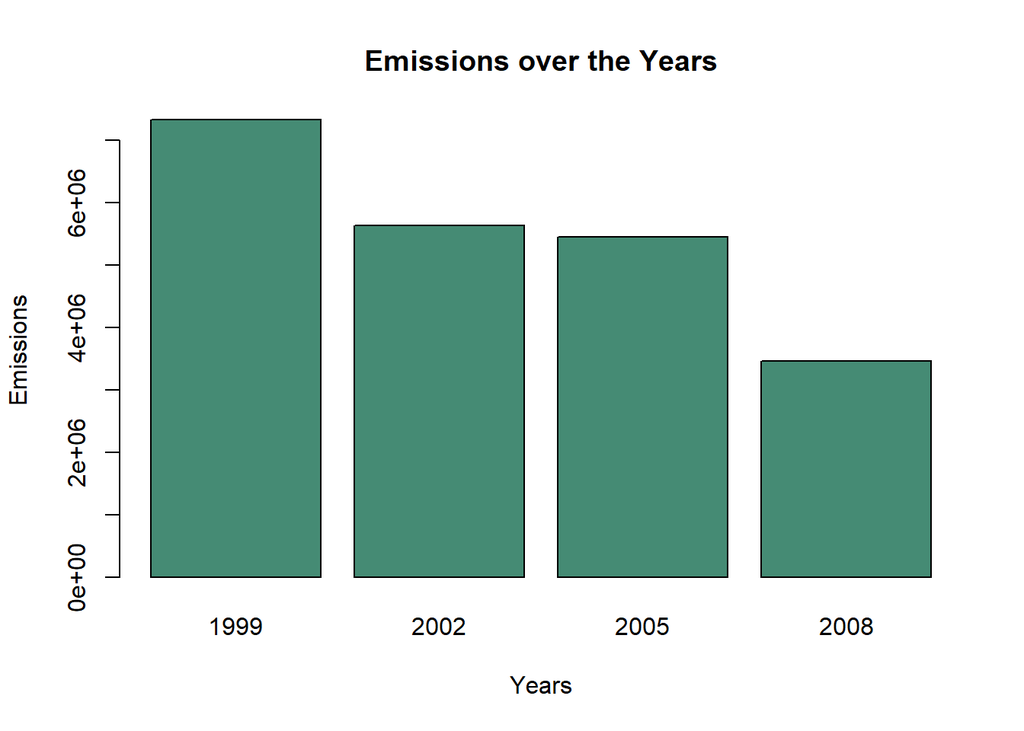

```r
NEI[, Emissions := lapply(.SD, as.numeric), .SDcols = c("Emissions")]

total_NEI <- NEI[, lapply(.SD, sum, na.rm = TRUE), .SDcols = c("Emissions"), by = year]

barplot(total_NEI[, Emissions]
        , names = total_NEI[, year]
        , xlab = "Years", ylab = "Emissions"
        , main = "Emissions over the Years", col = 'aquamarine4')
```

```r
png(filename='plot1.png')

dev.off()
```

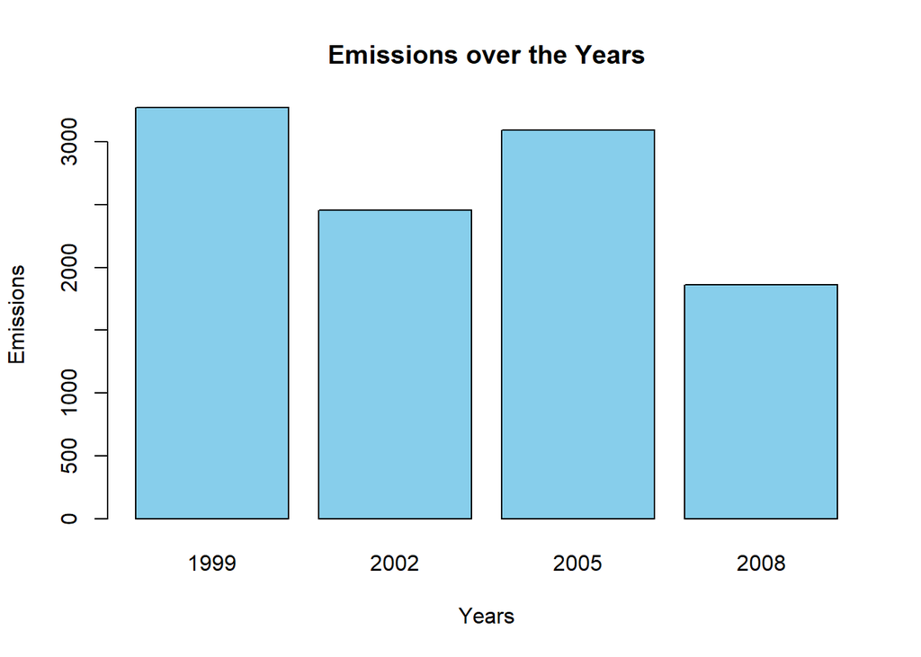

```r
NEI[, Emissions := lapply(.SD, as.numeric), .SDcols = c("Emissions")]
total_NEI <- NEI[fips=='24510', lapply(.SD, sum, na.rm = TRUE)
                , .SDcols = c("Emissions")
                , by = year]

barplot(total_NEI[, Emissions]
        , names = total_NEI[, year]
        , xlab = "Years", ylab = "Emissions"
        , main = "Emissions over the Years", col = 'skyblue')
```

```r
png(filename='plot2.png')

dev.off()
```

**Question 3: Of the four types of sources indicated by the 𝚝𝚢𝚙𝚎 (point, nonpoint, onroad, nonroad) variable, which of these four sources have seen decreases in emissions from 1999–2008 for Baltimore City? Which have seen increases in emissions from 1999–2008? Use the ggplot2 plotting system to make a plot answer this question?**

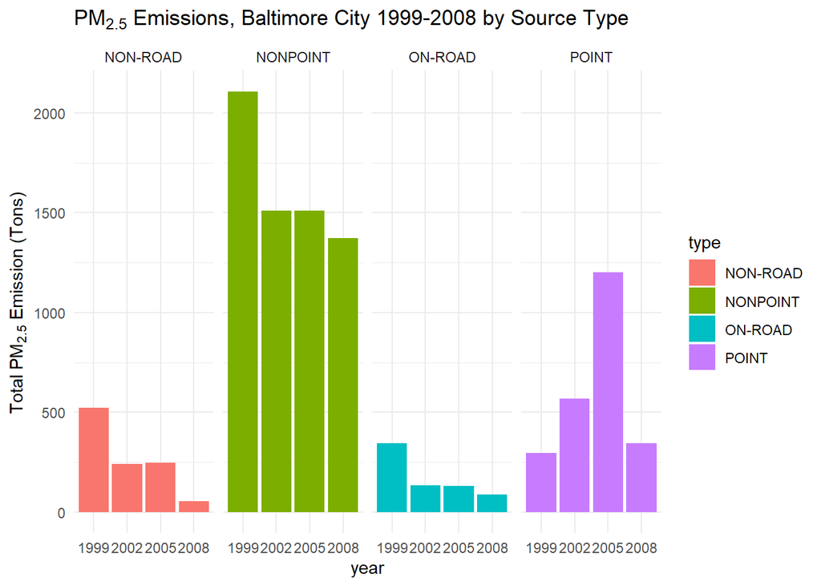

```r
baltimore_NEI <- NEI[fips=="24510",]

ggplot(baltimore_NEI,aes(factor(year),Emissions,fill=type)) +
  geom_bar(stat="identity") + theme_minimal() +
  facet_grid(.~type,scales = "free",space="free") +
  labs(x="year", y=expression("Total PM"[2.5]*" Emission (Tons)")) +
  labs(title=expression("PM"[2.5]*" Emissions, Baltimore City 1999-2008 by Source Type"))
```

```r
png("plot3.png")

dev.off()
```

**Question 4: Across the United States, how have emissions from coal combustion-related sources changed from 1999–2008?**

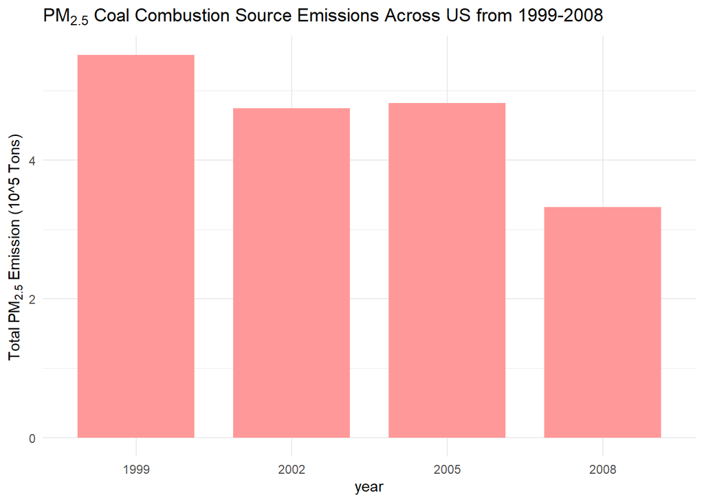

```r
combustion_Related <- grepl("comb", SCC[, SCC.Level.One], ignore.case=TRUE)
coal_Related <- grepl("coal", SCC[, SCC.Level.Four], ignore.case=TRUE)
combustion_SCC <- SCC[combustion_Related & coal_Related, SCC]
combustion_NEI <- NEI[NEI[,SCC] %in% combustion_SCC]


ggplot(combustion_NEI,aes(x = factor(year),y = Emissions/10^5)) +
  geom_bar(stat="identity", fill ="#FF9999", width=0.75) + theme_minimal() +
  labs(x="year", y=expression("Total PM"[2.5]*" Emission (10^5 Tons)")) +
  labs(title=expression("PM"[2.5]*" Coal Combustion Source Emissions Across US from 1999-2008"))
```

```r
png("plot4.png")

dev.off()
```

**Question 5: How have emissions from motor vehicle sources changed from 1999–2008 in Baltimore City?**

[figure not shown]

```r
condition <- grepl("vehicle", SCC[, SCC.Level.Two], ignore.case=TRUE)
vehicles_SCC <- SCC[condition, SCC]
vehicles_NEI <- NEI[NEI[, SCC] %in% vehicles_SCC,]

# Subset the vehicles NEI data to Baltimore's fip
baltimoreVehicles_NEI <- vehicles_NEI[fips=="24510",]

ggplot(baltimoreVehicles_NEI,aes(factor(year),Emissions)) +
  geom_bar(stat="identity", fill ="#FF9999" ,width=0.75) + theme_minimal() +
  labs(x="year", y=expression("Total PM"[2.5]*" Emission (10^5 Tons)")) +
  labs(title=expression("PM"[2.5]*" Motor Vehicle Source Emissions in Baltimore from 1999-2008"))
```

```r
png("plot5.png")

dev.off()
```

**Question 6: Compare emissions from motor vehicle sources in Baltimore City with emissions from motor vehicle sources in Los Angeles County, California (𝚏𝚒𝚙𝚜 == “𝟶𝟼𝟶𝟹𝟽”). Which city has seen greater changes over time in motor vehicle emissions?**

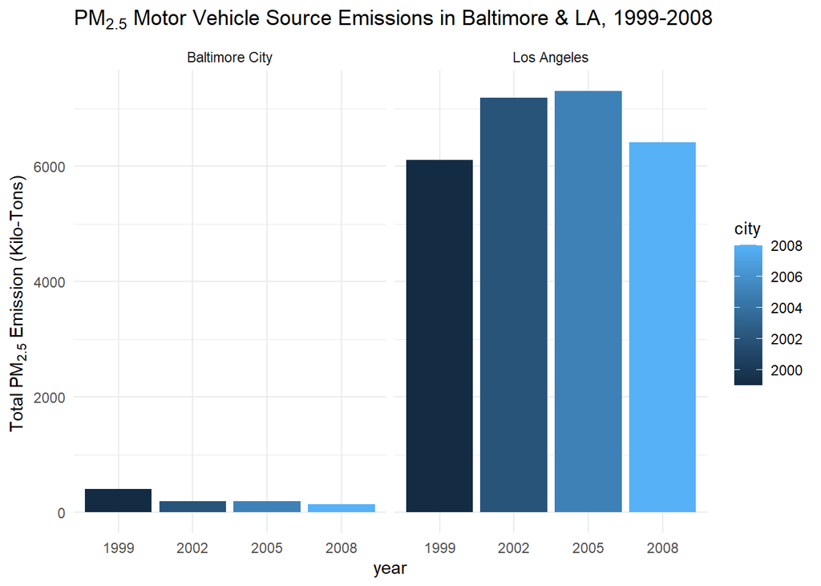

```r
condition <- grepl("vehicle", SCC[, SCC.Level.Two], ignore.case=TRUE)
vehicles_SCC <- SCC[condition, SCC]
vehicles_NEI <- NEI[NEI[, SCC] %in% vehicles_SCC,]

# Subset the vehicles NEI data by each city's fip and add city name.
vehiclesBaltimore_NEI <- vehicles_NEI[fips == "24510",]
vehiclesBaltimore_NEI[, city := c("Baltimore City")]

vehiclesLA_NEI <- vehicles_NEI[fips == "06037",]
vehiclesLA_NEI[, city := c("Los Angeles")]

# Combine data.tables into one data.table
both_NEI <- rbind(vehiclesBaltimore_NEI,vehiclesLA_NEI)

ggplot(both_NEI, aes(x=factor(year), y=Emissions, fill=city)) +
  geom_bar(aes(fill=year),stat="identity") + theme_minimal() +
  facet_grid(scales="free", space="free", .~city) +
  labs(x="year", y=expression("Total PM"[2.5]*" Emission (Kilo-Tons)")) +
  labs(title=expression("PM"[2.5]*" Motor Vehicle Source Emissions in Baltimore & LA, 1999-2008"))
```

```r
png("plot6.png")

dev.off()
```

**END**